# Analisis Salarios

- Show All Code
- Hide All Code

Author

Abelardo Morales

Published

October 10, 2023

Modified

October 16, 2023

Abstract

Resumen de salarios de futbolistas en ligas europeas

# 1 DATOS

Mediante técnicas de web scrapping se recolectaron datos de los salarios de futbolistas en ligas europeas actualizados a la fecha de hoy de los sitios:

- https://www.fichajes.com/
- https://www.kaggle.com/
- https://www.salaryexplorer.com/

Seguido a eso se exportaron a archivos csv y se estudiaron mediante R.

```r
library(readxl)
library(tidyverse)
library(rmarkdown)
library(knitr)
library(DT)
library(kableExtra)
library(here)
library(rstatix)
library(ggpubr)


options(scipen=999)


dfsalarios <- read_excel(here("Data/SalariosFut.xlsx"),
                       col_types = c("text", "text", "text",
                                     "date", "text"))
dfsalarios
## # A tibble: 258 × 5
##    JUGADOR          `SALARIO ANUAL` `SALARIO MENSUAL` HASTA               Equipo
##    <chr>            <chr>           <chr>             <dttm>              <chr>
##  1 Toni KroosT. Kr… 12,10M          1,01M             2023-06-30 00:00:00 Real …
##  2 David AlabaD. A… 11,00M          917K              2026-06-30 00:00:00 Real …
##  3 Luka ModrićL. M… 11,00M          917K              2023-06-30 00:00:00 Real …
##  4 Antonio Rüdiger… 9,00M           750K              2026-06-30 00:00:00 Real …
##  5 Thibaut Courtoi… 7,20M           600K              2026-06-30 00:00:00 Real …
##  6 NachoNacho ESP3… 5,70M           475K              2023-06-30 00:00:00 Real …
##  7 Daniel Carvajal… 5,00M           417K              2025-06-30 00:00:00 Real …
##  8 Lucas VázquezLu… 4,50M           375K              2024-06-30 00:00:00 Real …
##  9 Ferland MendyF.… 4,50M           375K              2025-06-30 00:00:00 Real …
## 10 Éder MilitãoÉde… 4,50M           375K              2025-06-30 00:00:00 Real …
## # ℹ 248 more rows
```

```r
kbl(head(dfsalarios[,-4], 15), align = "c", longtable = T) %>% kable_material_dark(full_width=T)
```

| JUGADOR | SALARIO ANUAL | SALARIO MENSUAL | Equipo |
| --- | --- | --- | --- |
| Toni KroosT. Kroos DEU33 años | 12,10M | 1,01M | Real Madrid |
| David AlabaD. Alaba AUTNGA31 años | 11,00M | 917K | Real Madrid |
| Luka ModrićL. Modrić HRV38 años | 11,00M | 917K | Real Madrid |
| Antonio RüdigerA. Rüdiger DEUSLE30 años | 9,00M | 750K | Real Madrid |
| Thibaut CourtoisT. Courtois BEL31 años | 7,20M | 600K | Real Madrid |
| NachoNacho ESP33 años | 5,70M | 475K | Real Madrid |
| Daniel CarvajalDani Carvajal ESP31 años | 5,00M | 417K | Real Madrid |
| Lucas VázquezLucas Vázquez ESP32 años | 4,50M | 375K | Real Madrid |
| Ferland MendyF. Mendy FRASEN28 años | 4,50M | 375K | Real Madrid |
| Éder MilitãoÉder Militão BRAESP25 años | 4,50M | 375K | Real Madrid |
| Eduardo CamavingaE. Camavinga FRACOG20 años | 4,00M | 333K | Real Madrid |
| Fede ValverdeF. Valverde URYESP25 años | 3,90M | 325K | Real Madrid |
| RodrygoRodrygo BRAESP22 años | 3,60M | 300K | Real Madrid |
| Aurélien TchouaméniA. Tchouaméni FRACMR23 años | 3,60M | 300K | Real Madrid |
| Vinícius JúniorVinícius Júnior BRAESP23 años | 3,20M | 267K | Real Madrid |

Debido a la forma en como se recolectaron los datos, fue necesario hacer “limpieza” de los mismos

```r
names(dfsalarios) <- str_replace(names(dfsalarios),
                                 pattern = " ", replacement = "_")

dfsalariosFut <-  dfsalarios %>%
  mutate(Edad=as.numeric( str_sub(JUGADOR, -7, -6)),
         NombreyP=str_sub(JUGADOR, 1, -8),
         Nombre=str_replace(NombreyP, "[A-Z]{3,}", ""),
         Pais_Origen=str_extract(JUGADOR, "[A-Z]{3,}"),
         Salario_a=str_replace(str_sub(SALARIO_ANUAL, 1, -2), ",", "."),
         Factor_anual=ifelse(
           str_sub(SALARIO_ANUAL, -1)=="M",
           1000000,
           1000),
         Salario_m=str_replace(str_sub(SALARIO_MENSUAL, 1, -2), ",", "."),
         Factor_mensual=ifelse(
           str_sub(SALARIO_MENSUAL, -1)=="M",
           1000000,
           1000),
         Salario_anual_EUR=as.numeric(Salario_a)*Factor_anual,
         Salario_mensual_EUR=as.numeric(Salario_m)*Factor_mensual,
         Salario_mensual_USD=Salario_mensual_EUR*1.05,
         Salario_mensual_MX=Salario_mensual_EUR*18.87) %>%
  select(Nombre,Edad, Pais_Origen,Salario_anual_EUR,Salario_mensual_EUR,
         Salario_mensual_USD, Salario_mensual_MX,
         Equipo, HASTA) %>%
  na.omit() %>%
  tibble()

dfsalariosFut
## # A tibble: 245 × 9
##    Nombre                 Edad Pais_Origen Salario_anual_EUR Salario_mensual_EUR
##    <chr>                 <dbl> <chr>                   <dbl>               <dbl>
##  1 Toni KroosT. Kroos       33 DEU                  12100000             1010000
##  2 David AlabaD. Alaba      31 AUTNGA               11000000              917000
##  3 Luka ModrićL. Modrić     38 HRV                  11000000              917000
##  4 Antonio RüdigerA. Rü…    30 DEUSLE                9000000              750000
##  5 Thibaut CourtoisT. C…    31 BEL                   7200000              600000
##  6 NachoNacho               33 ESP                   5700000              475000
##  7 Daniel CarvajalDani …    31 ESP                   5000000              417000
##  8 Lucas VázquezLucas V…    32 ESP                   4500000              375000
##  9 Ferland MendyF. Mend…    28 FRASEN                4500000              375000
## 10 Éder MilitãoÉder Mil…    25 BRAESP                4500000              375000
## # ℹ 235 more rows
## # ℹ 4 more variables: Salario_mensual_USD <dbl>, Salario_mensual_MX <dbl>,
## #   Equipo <chr>, HASTA <dttm>
```

# 2 ANALISIS

Ya con los datos en limpio, podemos obtener información acerca de estos

> Resumen

```r
dfsalariosFut %>% summary()
##     Nombre               Edad       Pais_Origen        Salario_anual_EUR
##  Length:245         Min.   :16.00   Length:245         Min.   :   12000
##  Class :character   1st Qu.:24.00   Class :character   1st Qu.: 1160000
##  Mode  :character   Median :27.00   Mode  :character   Median : 2990000
##                     Mean   :27.15                      Mean   : 3987796
##                     3rd Qu.:30.00                      3rd Qu.: 5830000
##                     Max.   :40.00                      Max.   :46800000
##  Salario_mensual_EUR Salario_mensual_USD Salario_mensual_MX    Equipo
##  Min.   :   1000     Min.   :   1050     Min.   :   18870   Length:245
##  1st Qu.:  97000     1st Qu.: 101850     1st Qu.: 1830390   Class :character
##  Median : 249000     Median : 261450     Median : 4698630   Mode  :character
##  Mean   : 332351     Mean   : 348969     Mean   : 6271464
##  3rd Qu.: 486000     3rd Qu.: 510300     3rd Qu.: 9170820
##  Max.   :3900000     Max.   :4095000     Max.   :73593000
##      HASTA
##  Min.   :2021-06-30 00:00:00.00
##  1st Qu.:2024-06-30 00:00:00.00
##  Median :2025-06-30 00:00:00.00
##  Mean   :2025-07-31 03:25:42.85
##  3rd Qu.:2026-06-30 00:00:00.00
##  Max.   :2031-06-30 00:00:00.00
```

## 2.1 EQUIPOS

Se utilizaron datos de los siguientes equipos:

> Clubes de futbol

```r
unique(dfsalariosFut$Equipo)
##  [1] "Real Madrid"        "Barcelona"          "Manchester United"
##  [4] "Liverpool"          "Bayer Munich"       "Juventus-fc"
##  [7] "Psg"                "Ac Milan"           "Chelsea"
## [10] "Borussia Dortmund"  "Valencia-Fc"        "Atletico de Madrid"
## [13] "Sevilla FC"         "Fulham"             "Everton FC"
## [16] "Brentford FC"
```

## 2.2 PAIS DE ORIGEN

> Pais de origen de los jugadores

```r
unique(dfsalariosFut$Pais_Origen)
##   [1] "DEU"    "AUTNGA" "HRV"    "DEUSLE" "BEL"    "ESP"    "FRASEN" "BRAESP"
##   [9] "FRACOG" "URYESP" "FRACMR" "ESPMAR" "UKR"    "POL"    "FRABEN" "BRAITA"
##  [17] "NLD"    "DNK"    "ENGKNA" "ENGTTO" "FRAMTQ" "ENG"    "PRT"    "SWE"
##  [25] "BRA"    "ENGCOD" "ARG"    "NLDCUW" "EGY"    "NLDSUR" "CMR"    "URY"
##  [33] "NLDTGO" "GRC"    "COL"    "SCO"    "ENGGMB" "IRL"    "ENGJAM" "DEUFRA"
##  [41] "FRAGNB" "FRAGLP" "DEUCIV" "MARNLD" "CMRDEU" "SENFRA" "DEUENG" "FRAGIN"
##  [49] "SRB"    "FRA"    "ITA"    "URYITA" "BRAPRT" "MARESP" "FRACOD" "GNBPRT"
##  [57] "FRACIV" "FRAESP" "ENGCAN" "FRAGUF" "DZAFRA" "PRTAGO" "BIH"    "DEUFIN"
##  [65] "ENGDOM" "BRAFRA" "ENGNGA" "ALBENG" "ENGSLE" "ENGITA" "USAPOL" "DEUTUR"
##  [73] "DEUCMR" "DEUNGA" "TURDEU" "ARGITA" "NOR"    "CHE"    "DEUUSA" "GEO"
##  [81] "PRTCPV" "SVN"    "NLDGHA" "MNE"    "BELMTQ" "MOZ"    "HRVCHE" "ARGESP"
##  [89] "SRBNLD" "MAR"    "NLDMOZ" "SCOENG" "JAMENG" "USA"    "BRABEL" "USAENG"
##  [97] "SVK"    "MLIFRA" "ENGIRL" "BELSEN" "SEN"    "DNKGMB" "CODFRA" "ALB"
## [105] "NGA"    "CMRFRA"
```

> Resumen país de origen

```r
fut_pais <- dfsalariosFut %>%
  group_by(Pais_Origen) %>%
  summarise(Conteo=n()) %>%
  arrange(desc(Conteo))
# Pais de origen de los jugadores ordenados de mayor a menor

kbl(head(fut_pais, 15), align = "c") %>% kable_material_dark(full_width=FALSE)
```

| Pais_Origen | Conteo |
| --- | --- |
| ESP | 30 |
| ENG | 19 |
| DEU | 17 |
| ITA | 15 |
| BRA | 8 |
| PRT | 7 |
| DNK | 6 |
| FRACOD | 5 |
| ARG | 4 |
| BRAESP | 4 |
| ENGJAM | 4 |
| FRA | 4 |
| FRACIV | 4 |
| SCO | 4 |
| SRB | 4 |

Podemos ver de donde provienen la mayoria de jugadores de estas ligas

Pais origen

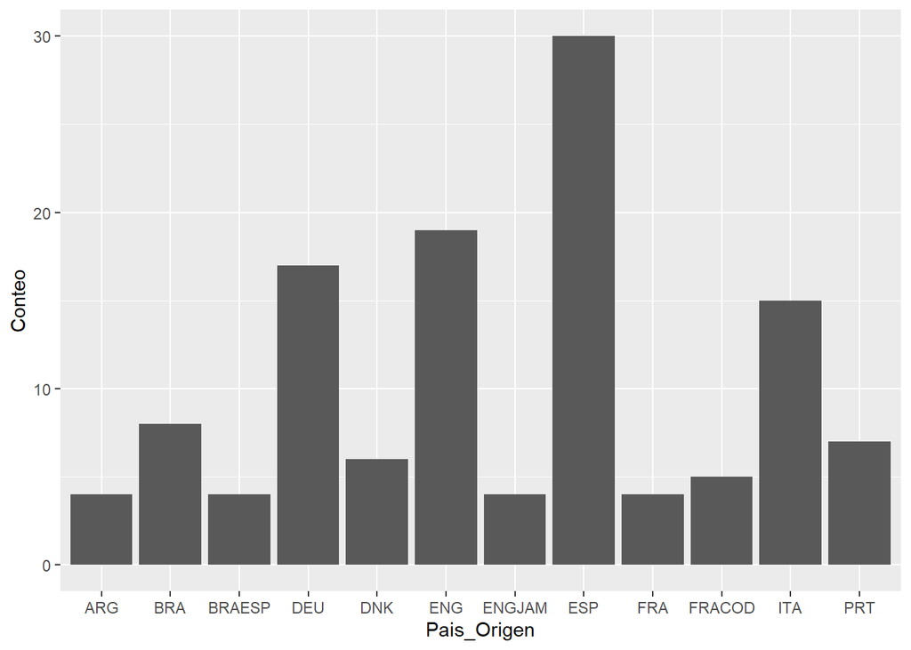

```r
ggplot(head(fut_pais, n = 12), mapping = aes(x = Pais_Origen, y = Conteo))+
  geom_col()
```

Pais-origen

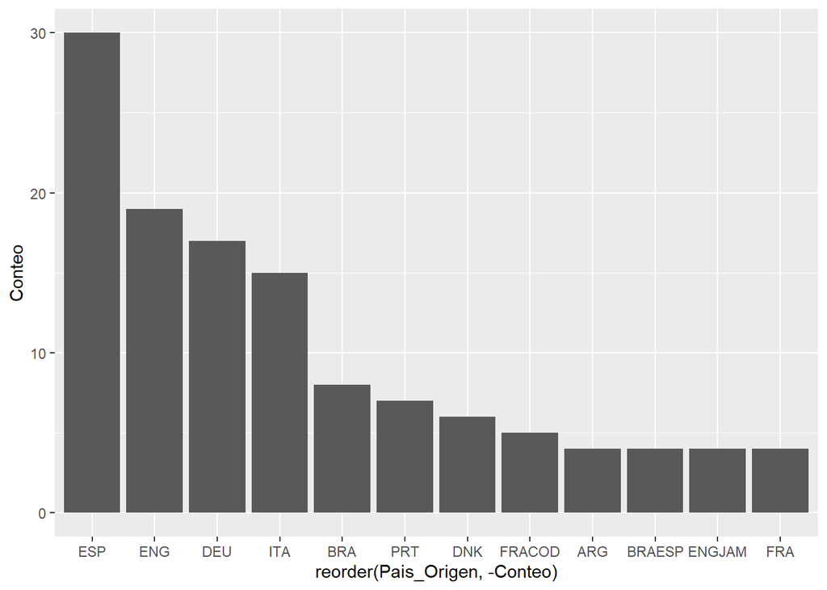

```r
ggplot(head(fut_pais, n = 12),
       mapping = aes(x = reorder(Pais_Origen, -Conteo),
                     y = Conteo))+
  geom_col()
```

## 2.3 EDAD

> Aqui vemos el rango de edad de los jugadores

Edad

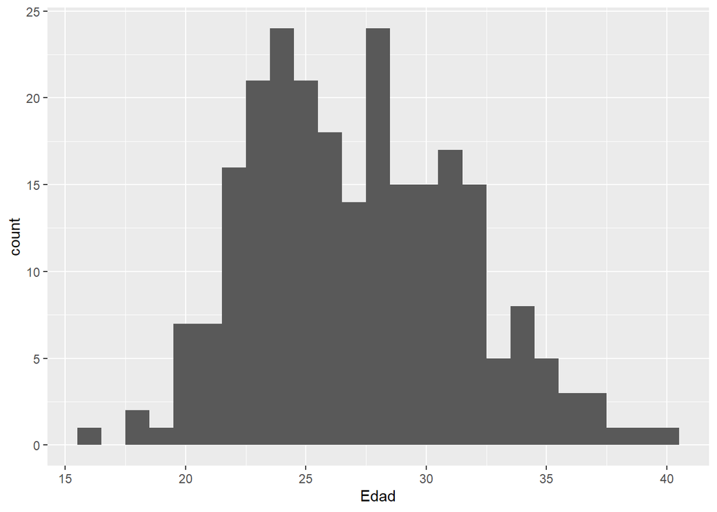

```r
dfsalariosFut %>%
  ggplot(aes(Edad))+
  geom_histogram(bins = 25)
```

## 2.4 SALARIOS

Para estudiar los salarios, se realizo la conversion a diferentes tipos de cambio

Se muestran los resultados en peso mexicano (MX), unicameente con el propósito de que las cantidades sean familiares

> Jugador mejor pagado

```r
dfsalariosFut %>%
  filter(Salario_mensual_MX==max(Salario_mensual_MX, na.rm = T)) %>% select(Nombre, Salario_mensual_EUR, Salario_mensual_MX) %>%
  kbl(format.args = list(big.mark = ','))
```

| Nombre | Salario_mensual_EUR | Salario_mensual_MX |
| --- | --- | --- |
| Kylian MbappéK. Mbappé | 3,900,000 | 73,593,000 |

> El “peor pagado”

```r
dfsalariosFut %>%
  filter(Salario_mensual_MX==min(Salario_mensual_MX, na.rm = T)) %>% select(Nombre, Salario_mensual_EUR, Salario_mensual_MX) %>%
  kbl(format.args = list(big.mark = ','))
```

| Nombre | Salario_mensual_EUR | Salario_mensual_MX |
| --- | --- | --- |
| Giovanni GarofaniG. Garofani | 1,000 | 18,870 |

> Desviación estándar

```r
sd(dfsalariosFut$Salario_mensual_MX) %>%
  tibble("Desviación Estandar"=.) %>%
  kbl(format.args = list(big.mark = ','))
```

| Desviación Estandar |
| --- |
| 6,748,445 |

SD

Esto podria sugerir que los salarioss son muy desiguales, asi que veamos

> Promedio

```r
dfsalariosFut$Salario_mensual_MX %>%
  mean(na.rm = T)%>%
  tibble("Promedio"=.) %>%
  kbl(format.args = list(big.mark = ','))
```

| Promedio |
| --- |
| 6,271,464 |

trim=0

> El promedio ajustado de salario mensual en pesos

```r
dfsalariosFut$Salario_mensual_MX %>%
  mean(trim = 0.05, na.rm = T)%>%
  tibble("Promedio Ajustado"=.) %>%
  kbl(format.args = list(big.mark = ','))
```

| Promedio Ajustado |
| --- |
| 5,709,157 |

trim=0.05

### 2.4.1 ANALISIS DE DISTRIBUCION

Comportamiento del salario en relacion a los jugadores

Densidad Salario

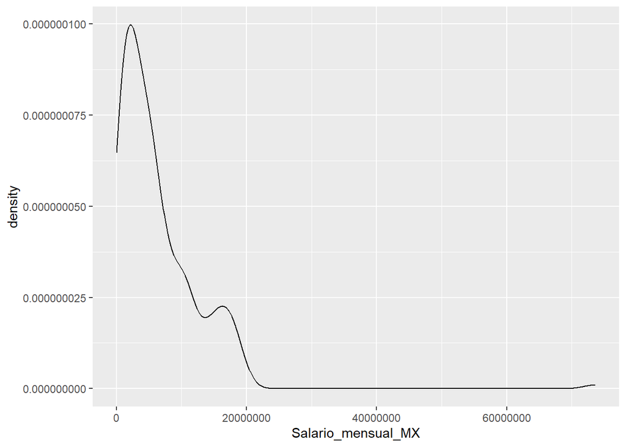

```r
ggplot(dfsalariosFut, aes(Salario_mensual_MX))+
  geom_density()
```

Distribución salario

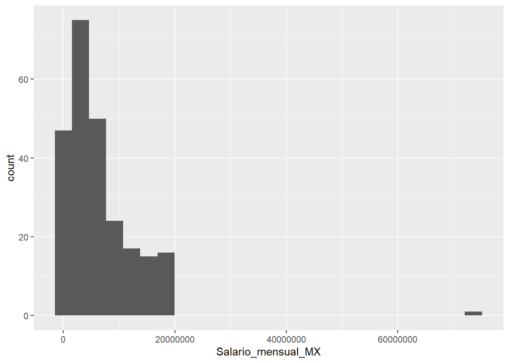

```r
ggplot(dfsalariosFut, aes(Salario_mensual_MX))+
  geom_histogram(bins=25)
```